# HDT2-Clustering

Andres Quinto, Mirka Monzon, Oscar De Leon

20/02/2022

```r
datos <- read.csv("movies.csv")
library(hopkins)
```

## Hoja de trabajo no.2

### Clustering

1. Haga el preprocesamiento del dataset, explique qué variables no aportan información a la generación de grupos y por qué. Describa con qué variables calculará los grupos.

```r
variable <- c("id", "original_title", "originalLanguage", "homePage", "video", "actorsCharacter")
DataFrame.Variables <- data.frame(variable)
print(DataFrame.Variables)
```

```
##           variable
## 1               id
## 2   original_title
## 3 originalLanguage
## 4         homePage
## 5            video
## 6  actorsCharacter
```

Las variables listadas anteriormente, son las variables que considereamos no aportan informacion a la generacion de grupos ya que cada una de ellas tienen caracteristicas propias que no se relacionan con las demas y/o contienen informacion no usable.

2. Analice la tendencia al agrupamiento usando el estadístico de Hopkings y la VAT (Visual Assessment of cluster Tendency). Discuta sus resultados e impresiones.

Para ello necesitamos normalizar los datos de la db. Referencia para la funcion de hopkins https://www.rdocumentation.org/packages/clustertend/versions/1.5/topics/hopkins

```r
library(hopkins) #Con esto revisamos el agrupamiento.

datos <- read.csv("movies.csv")

datos<-datos[complete.cases(read.csv("movies.csv")),]
popularity<-datos[,'popularity']
budget<-datos[,'budget']
revenue<-datos[,'revenue']
runtime<-datos[,'runtime']
voteCount<-datos[,'voteCount']
NORMD<-data.frame(popularity,budget,revenue,runtime,voteCount)
Clustering<-scale(NORMD)

hopkins(Clustering)
```

```
## [1] 0.9953071
```

```r
#Matriz de distancia
DistData<- dist(Clustering)
```

Se puede apreciar que el valor que retorna la funcion de hopkins esta muy alejado de 0.5, es decir los datos recopilados no son aleatorios, dandonos a entender que el agrupamiento se puede facilitar. Para ello utilizaremos y analizaremos de forma grafica los datos.

Referencia a la libreria: https://cloud.r-project.org/web/packages/factoextra/factoextra.pdf

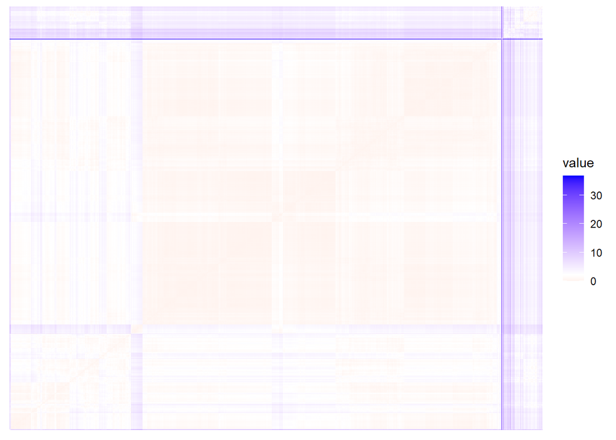

```r
library(ggplot2)
library(factoextra) #Paquete que facilita los graficos de clustering
knitr::opts_chunk$set(fig.width=12, fig.height=8)
fviz_dist(DistData, show_labels = F)
```

3. Determine cuál es el número de grupos a formar más adecuado para los datos que está trabajando. Haga una gráfica de codo y explique la razón de la elección de la cantidad de clústeres con la que trabajará.

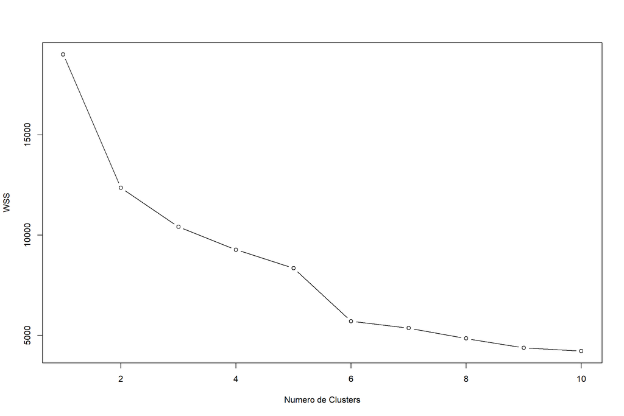

```r
wss = 0
for (i in 1:10)
  wss[i] <- sum(kmeans(Clustering[,1:5], centers=i)$withinss)
plot(1:10, wss, type="b", xlab="Numero de Clusters",  ylab="WSS")
```

4. Utilice 3 algoritmos existentes para el agrupamiento. Compare los resultados generados por cada uno.

Agrupamiento por medio de k-means Referencia de la libreria para k-means; https://cran.r-project.org/web/packages/fpc/fpc.pdf

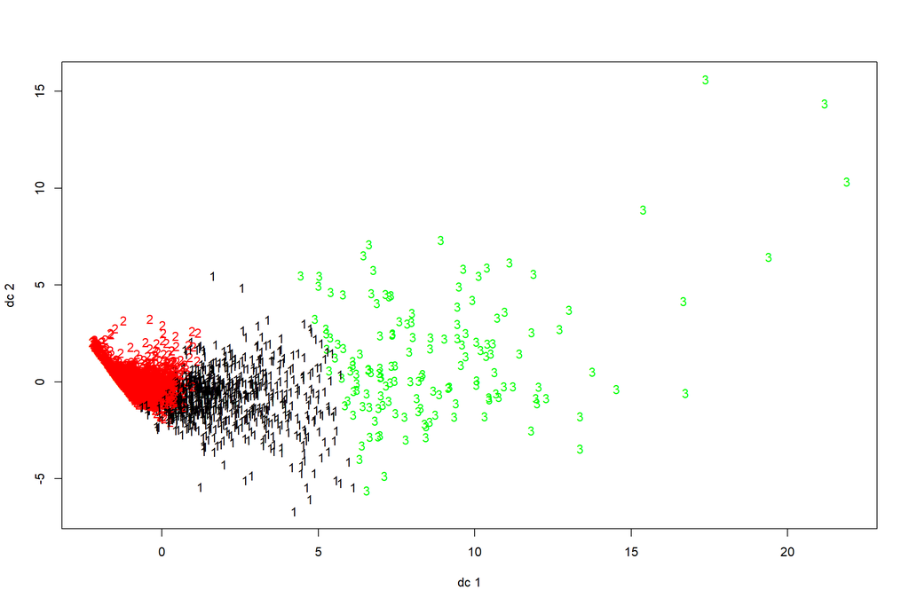

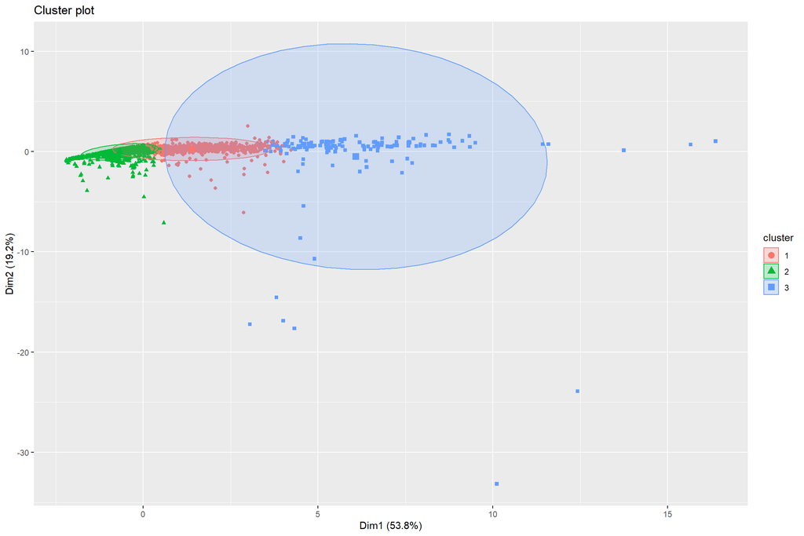

```
## [1] 0.4645744
```

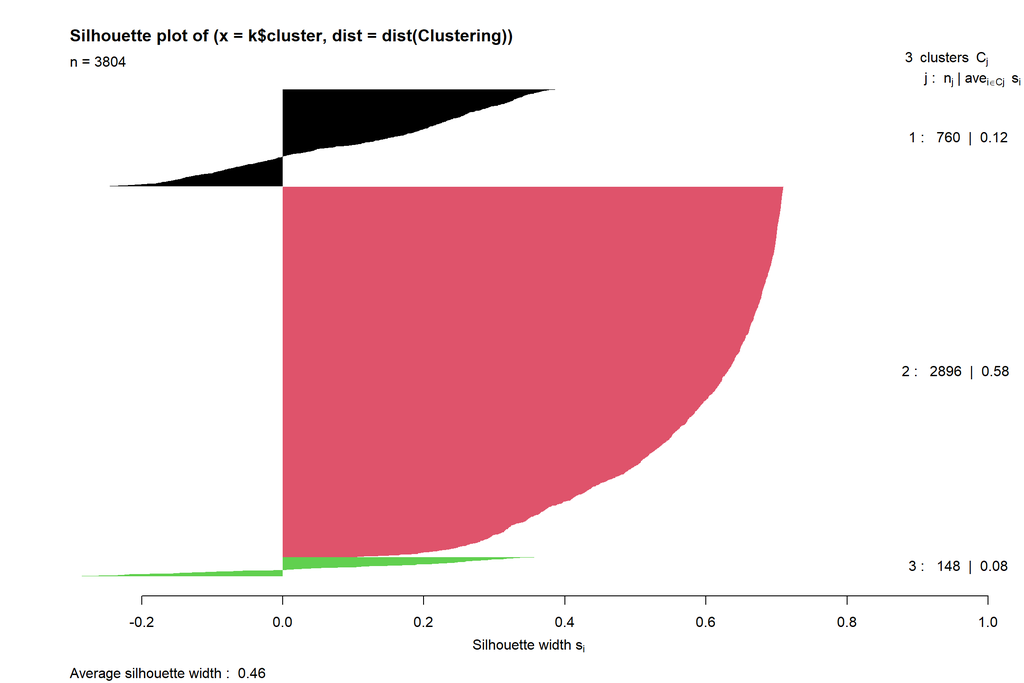

Cluster jerarquico Para el cluster jerarquico se agrupan los datos basandose en la distancia que tienen entre si, de forma que los datos dentro de este cluster sean con mayor similitud entre si.

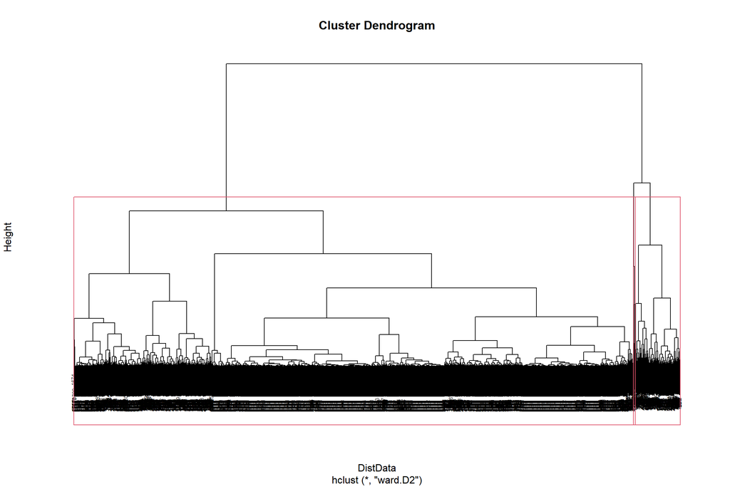

```r
library(cluster)
Matrix<- dist(Clustering)
hc<-hclust(DistData, method = "ward.D2") #se genera el cluster jerarquico
plot(hc, cex=0.5, axes=FALSE)#Utilizamos un dendograma
rect.hclust(hc,k=3)
```

```r
groups<-cutree(hc,k=3) #Determinamos el grupo de cada fila, cortando el grafico
datos$gruposHC<-groups

silhc<-silhouette(groups,DistData)
mean(silhc[,3])
```

```
## [1] 0.6706415
```

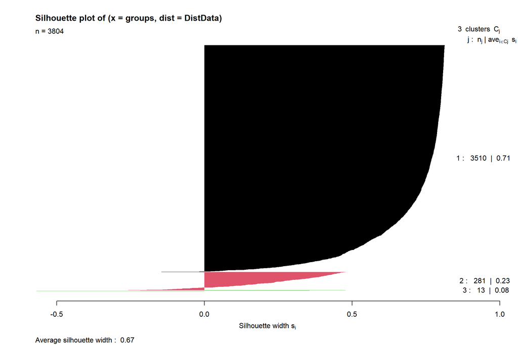

```r
Jerarquico<-mean(silhc[,3])

plot(silhc, cex.names=.4, col=1:3, border = NA)
```

Mezcla de gaussiano Esta mezcla determina que todos los datos que se generan conforman una mezcla de distribuciones gaussianas de forma finita.

Referencia a la libreria de agrupamiento: https://cran.r-project.org/web/packages/mclust/index.html

```r
library(cluster)
library(mclust)
mclust<-Mclust(Clustering,3)
datos$mxGau<-mclust$classification
silmg<-silhouette(mclust$classification,DistData)
mean(silmg[,3])
```

```
## [1] 0.09986342
```

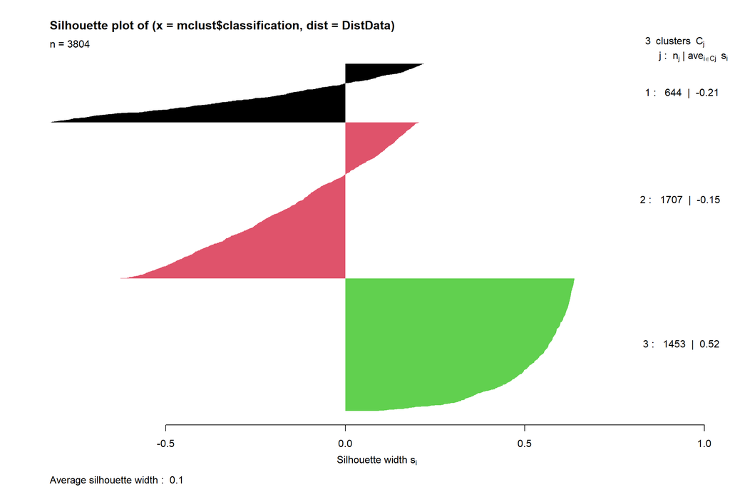

```r
Gauss<-mean(silmg[,3])
plot(silmg, cex.names=.4, col=1:3, border = NA)
```

Podemos observar, que con este algoritmo obtuvimos 0.0998634 de promedio de la silueta, el valor es mas cercano a 0 que a 1, gracias a que posee demasiadas siluetas negativas.

El valor es mas cercano a 0 que a 1, gracias a que posee demasiadas siluetas negativas.

5. Determine la calidad del agrupamiento hecho por cada algoritmo con el método de la silueta. Discuta los resultados.

#####k-mean

#####Cluster jerarquico

Como se puede en la grafica realizada con el metodo de la silueta en el inciso anterior, se puede ver que los clusters involucrados son coherentes en la gran mayoria, solo con algunos datos atipicos.

#####Mezcla de gaussiano

Como se puede en la grafica realizada con el metodo de la silueta en el inciso anterior, esta grafica se obtuvo un mayor de datos atipicos, casi iguales a los datos ‘normales’, solo la terccera agrupacion es totalmete coherente y el coeficiente es mas cercano a 0.

6. Interprete los grupos basado en el conocimiento que tiene de los datos. Recuerde investigar las medidas de tendencia central de las variables continuas y las tablas de frecuencia de las variables categóricas pertenecientes a cada grupo. Identifique hallazgos interesantes debido a las agrupaciones y describa para qué le podría servir.

```r
mean(x = NORMD$popularity, na.rm = TRUE)
```

```
## [1] 68.1854
```

La media de la popularidad es 68.1854

```r
mean(x = NORMD$budget, na.rm = TRUE)
```

```
## [1] 24335422
```

La media de presupuesto es 24335422

```r
mean(x = NORMD$revenue, na.rm = TRUE)
```

```
## [1] 78593938
```

```r
mean(x = NORMD$runtime, na.rm = TRUE)
```

```
## [1] 103.2592
```

La media de runtime es de 103.2592

```r
round(mean(x = NORMD$voteCount, na.rm = TRUE))
```

```
## [1] 1871
```

La media de votos es 1871

```r
tabla <- table(NORMD$popularity)
head(sort(tabla, decreasing = TRUE), n = 15)
```

```
##
## 15.804 39.372   8.54  9.336   9.34  9.363  9.608   9.83 10.171 10.192 10.243
##      3      3      2      2      2      2      2      2      2      2      2
## 10.303 10.393 10.472 10.767
##      2      2      2      2
```

La moda de la popularidad es compartida entre 15.804 y 39.372 con 3 repeticiones cada una.

```r
tabla <- table(NORMD$budget)
head(sort(tabla, decreasing = TRUE), n = 15)
```

```
##
##         0  20000000  10000000  30000000  15000000  40000000  25000000  50000000
##      1688        84        81        77        70        68        57        56
##   5000000  35000000  60000000  12000000 100000000 150000000   4000000
##        52        45        45        42        34        33        32
```

La moda de presupuestos es de 20000000 con 84 repeticiones. El valor 0 ha sido ignorado debido a que se considera un NA o NULL.

```r
tabla <- table(NORMD$revenue)
head(sort(tabla, decreasing = TRUE), n = 15)
```

```
##
##        0    7e+06     5000    2e+06  3600000  4100000  1.4e+07  1.9e+07
##     1558        3        2        2        2        2        2        2
## 21200000  2.6e+07  2.7e+07    3e+07 34100000  4.3e+07 43300000
##        2        2        2        2        2        2        2
```

La moda de los infresos es 7e+06 con 3 repeticiones. El valor 0 es ignorado debido a que se considera un NA o NuLL.

```r
tabla <- table(NORMD$runtime)
head(sort(tabla, decreasing = TRUE), n = 15)
```

```
##
##  90 100  97  93 102 110  92  95  94 107  96 108  98 109 104
## 143 115  98  93  90  88  86  86  84  84  83  83  82  82  80
```

La moda de runtime es 90 con 143 repeticiones.

```r
tabla <- table(NORMD$voteCount)
head(sort(tabla, decreasing = TRUE), n = 15)
```

```
##
##   4  18 179   6  13  52  65   3  34  46  57  90 215   1   2
##  15  13  12  11  11  11  11  10  10  10  10  10  10   9   9
```

La moda de votos por pelicula es de 4 con 15 repeticiones.